# BeerBreweries

# 7. Is there an apparent relationship between the bitterness of the beer and its alcoholic content?

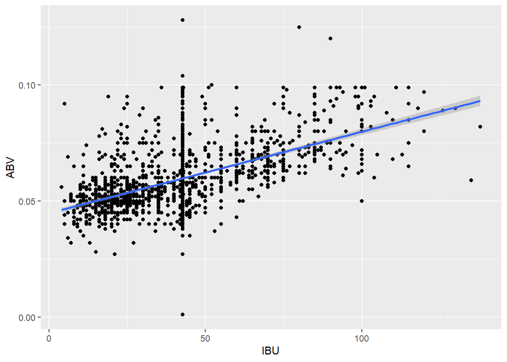

```r
# .52 correlation, some correlation between the bitterness of beer and it's alcoholic content, however it is not strong (scale -1 to 1).

# Scatter plot
ggplot(merged, aes(x=IBU, y=ABV)) + geom_point() + geom_smooth(method=lm)
```

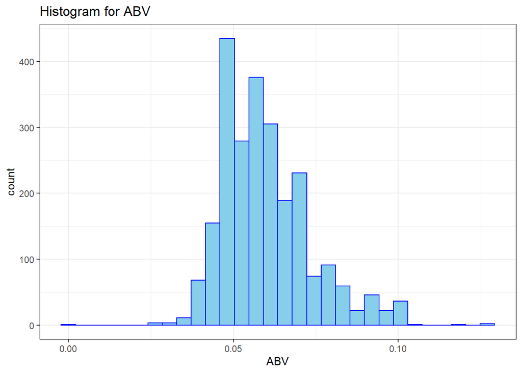

```r
# Histogram
ggplot(merged, aes(x = ABV)) +
  geom_histogram(color="blue", fill="skyblue") +
  theme_bw() +
  ggtitle("Histogram for ABV")
```

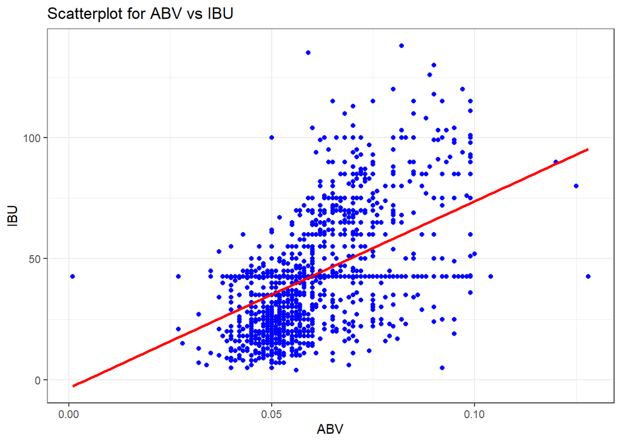

```r
# Scatter plot
ggplot(df2, aes(x = ABV, y = IBU)) +
  geom_point(color = "blue")+
  geom_smooth(method = "lm",se = F, color = "red")+
  ggtitle("Scatterplot for ABV vs IBU") +
  theme_bw()
```

```r
summary(merged$ABV)
```

```
##    Min. 1st Qu.  Median    Mean 3rd Qu.    Max.
## 0.00100 0.05000 0.05700 0.05977 0.06700 0.12800
```

```r
# Correlation test
cor.test(merged$ABV,merged$IBU)
```

```
##
##  Pearson's product-moment correlation
##
## data:  merged$ABV and merged$IBU
## t = 29.875, df = 2408, p-value < 2.2e-16
## alternative hypothesis: true correlation is not equal to 0
## 95 percent confidence interval:
##  0.4902622 0.5485495
## sample estimates:
##      cor
## 0.520011
```

# 8. Budweiser would also like to investigate the difference with respect to IBU and ABV between IPAs (India Pale Ales) and other types of Ale (any beer with “Ale” in its name other than IPA). You decide to use KNN classification to investigate this relationship. Provide statistical evidence one way or the other.

```r
minDF = subset(merged, select = c("ABV","IBU","Style","State"),
               is.na(ABV) == FALSE & is.na(IBU) == FALSE)

minDF$S1 = NA

for(k in 1:nrow(minDF))
{
  if(grepl("IPA", minDF$Style[k], fixed = TRUE) == TRUE)
  {
    minDF$S1[k] = "IPA"
  }
  else if(grepl("Ale", minDF$Style[k], fixed = TRUE) == TRUE)
  {
    minDF$S1[k] = "Ale"
  }
}
```

```r
clsdf = subset(minDF, select = c("ABV","IBU","S1","State"), is.na(S1) == FALSE)
clsdf = dplyr::rename(clsdf,Style = S1)
```

# Scatterplot graphing the relationship of ABV and IBU in terms of Ale and IPA

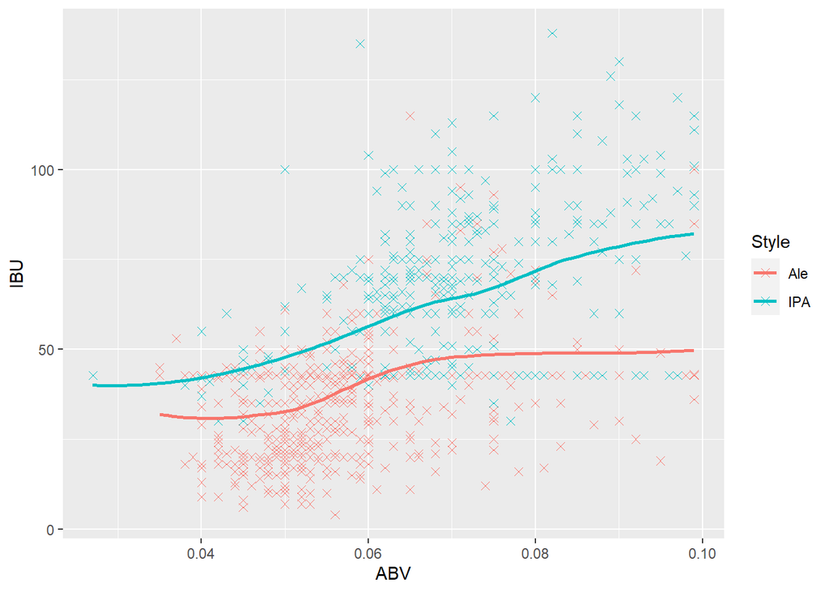

```r
ggplot(clsdf,aes(ABV,IBU,color=Style))+
  geom_point(shape=4,size=2)+
  geom_smooth(method=loess,se=F)
```

# Box plot of ABV in Ale and IPA

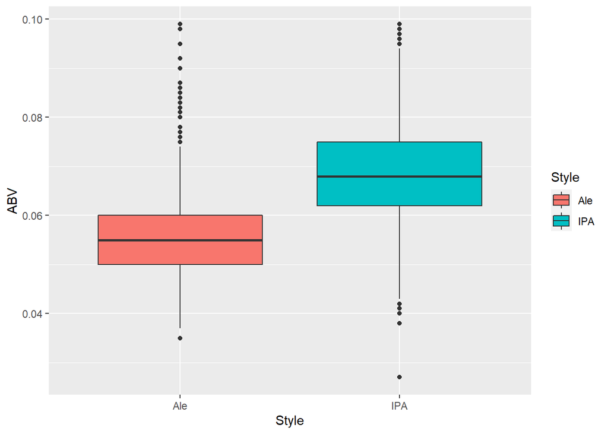

```r
ggplot(clsdf,aes(Style,ABV,fill=Style))+geom_boxplot()
```

# Box plot of IBU in Ale and IPA

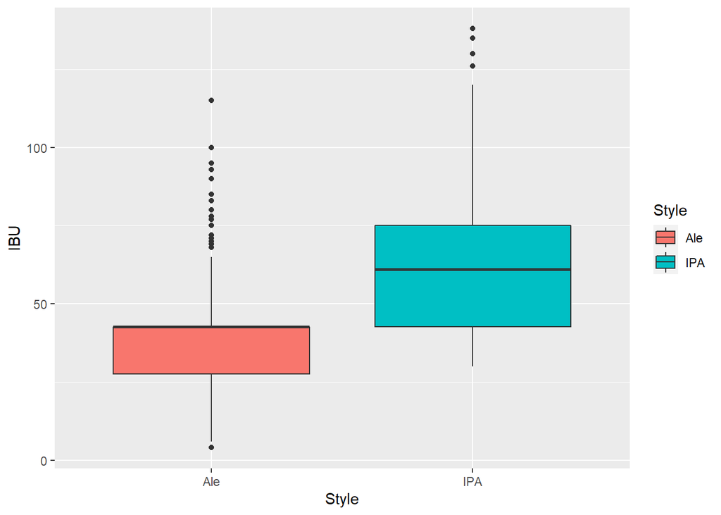

```r
ggplot(clsdf,aes(Style,IBU,fill=Style))+geom_boxplot()
```

# The relationship between IBU and ABV in terms of Style(Ale,IPA)

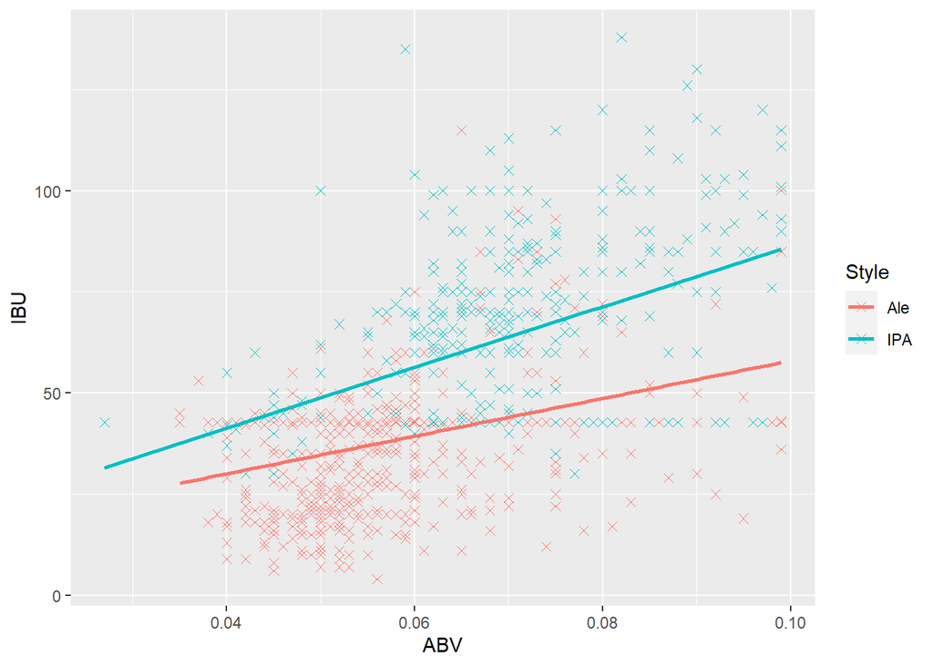

```r
ggplot(clsdf,aes(ABV,IBU,color=Style))+
  geom_point(shape=4,size=2)+
geom_smooth(method=lm,se=F)
```

# To Compare Two Variances

```r
var.test(IBU~Style,data=clsdf)
```

```
##
##  F test to compare two variances
##
## data:  IBU by Style
## F = 0.45314, num df = 962, denom df = 570, p-value < 2.2e-16
## alternative hypothesis: true ratio of variances is not equal to 1
## 95 percent confidence interval:
##  0.3907924 0.5239735
## sample estimates:
## ratio of variances
##          0.4531407
```

# Two variance were different

```r
ale=subset(clsdf,Style=="Ale")
ipa=subset(clsdf,Style=="IPA")
```

# To test normality of the variables

```r
shapiro.test(ale$IBU)
```

```
##
##  Shapiro-Wilk normality test
##
## data:  ale$IBU
## W = 0.89391, p-value < 2.2e-16
```

```r
shapiro.test(ipa$IBU)
```

```
##
##  Shapiro-Wilk normality test
##
## data:  ipa$IBU
## W = 0.8946, p-value < 2.2e-16
```

```r
shapiro.test(ale$ABV)
```

```
##
##  Shapiro-Wilk normality test
##
## data:  ale$ABV
## W = 0.91104, p-value < 2.2e-16
```

```r
shapiro.test(ipa$ABV)
```

```
##
##  Shapiro-Wilk normality test
##
## data:  ipa$ABV
## W = 0.96982, p-value = 1.882e-09
```

```r
# The variables do not have a normal distribution
```

# Plot the normality of the variables

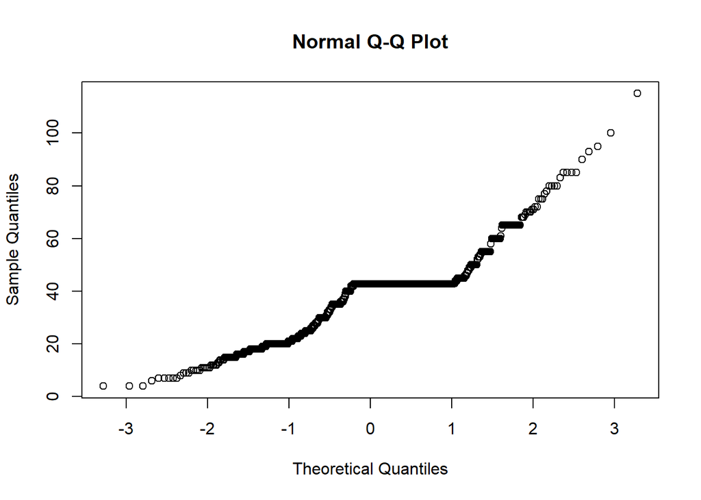

```r
qqnorm(ale$IBU)
```

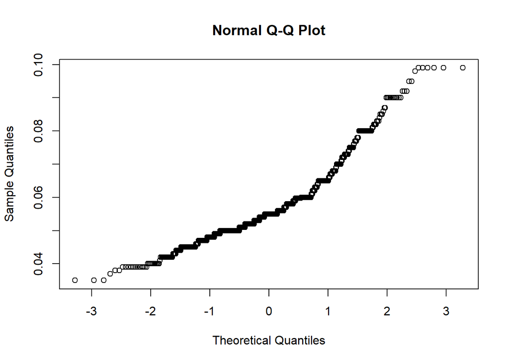

```r
qqnorm(ale$ABV)
```

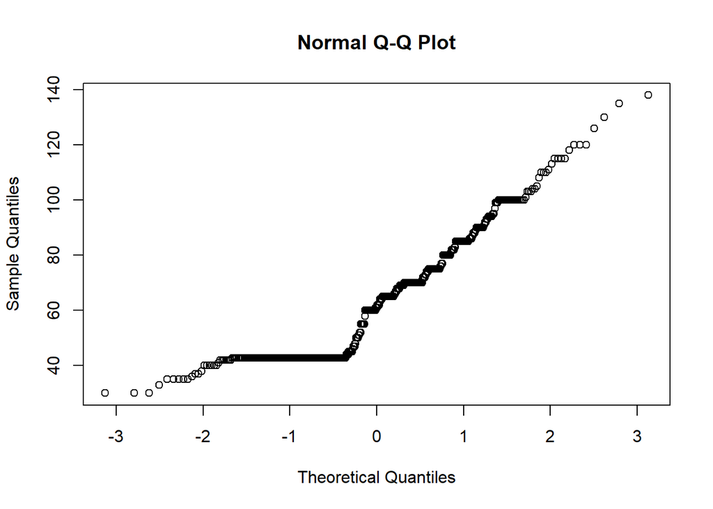

```r
qqnorm(ipa$IBU)
```

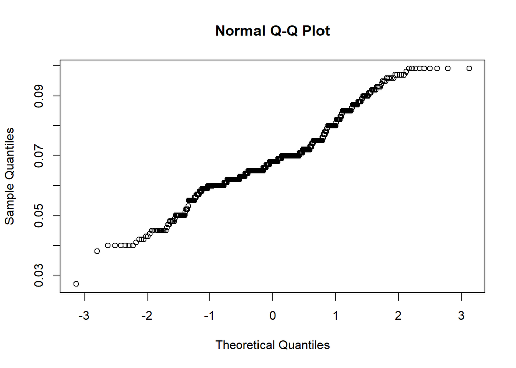

```r
qqnorm(ipa$ABV)
```

# Test the difference between ABV in different styles(IPA and Ale), we should use Mann Whiteny test

```r
wilcox.test(clsdf$ABV ~ clsdf$Style)
```

```
##
##  Wilcoxon rank sum test with continuity correction
##
## data:  clsdf$ABV by clsdf$Style
## W = 116495, p-value < 2.2e-16
## alternative hypothesis: true location shift is not equal to 0
```

```r
# ABV and Style had a significant difference
```

#ABV and Style had a significant difference

```r
wilcox.test(clsdf$IBU ~ clsdf$Style)
```

```
##
##  Wilcoxon rank sum test with continuity correction
##
## data:  clsdf$IBU by clsdf$Style
## W = 91907, p-value < 2.2e-16
## alternative hypothesis: true location shift is not equal to 0
```

```r
# IBU and Style had a significant difference
```

# Using KNN:

```r
clsdf = subset(clsdf, select = c("ABV","IBU","Style"))
idx = sample.int(n = nrow(clsdf), size = floor(0.7*nrow(clsdf)), replace = F)
train = clsdf[idx,]
test = clsdf[-idx,]
trn_target = train$Style
trn = train[,-3]
tst_target = test$Style
tst = test[,-3]

pred = knn(train = trn, test = tst, cl = trn_target, k = 6)
```

```r
head(pred)
```

```
## [1] Ale Ale IPA Ale Ale IPA
## Levels: Ale IPA
```

# To show confusion matrix:

```r
model_table=table(tst_target,pred)
model_table
```

```
##           pred
## tst_target Ale IPA
##        Ale 254  42
##        IPA  45 120
```

# To test the accuracy:

```r
sum(diag(model_table))/nrow(tst)
```

```
## [1] 0.8112798
```

```r
Accuracy = NULL
mis = NULL
sen = NULL
spe = NULL

for(i in 1:50)
{
  pred = knn(train = trn, test = tst, cl = trn_target, k = i)
  head(pred)
  model_table=table(trn_target)
  tab = table(Predicted = pred, Real = tst_target)
  Accuracy[i] = ((tab[1,1] + tab[2,2])/sum(tab))*100
  mis[i] = round((tab[1,2]+tab[2,1])/sum(tab),2)
  sen[i] = round(tab[2,2]/(tab[2,2]+tab[1,2]),2)
  spe[i] = round(tab[1,1]/(tab[1,1]+tab[2,1]),2)
}
```

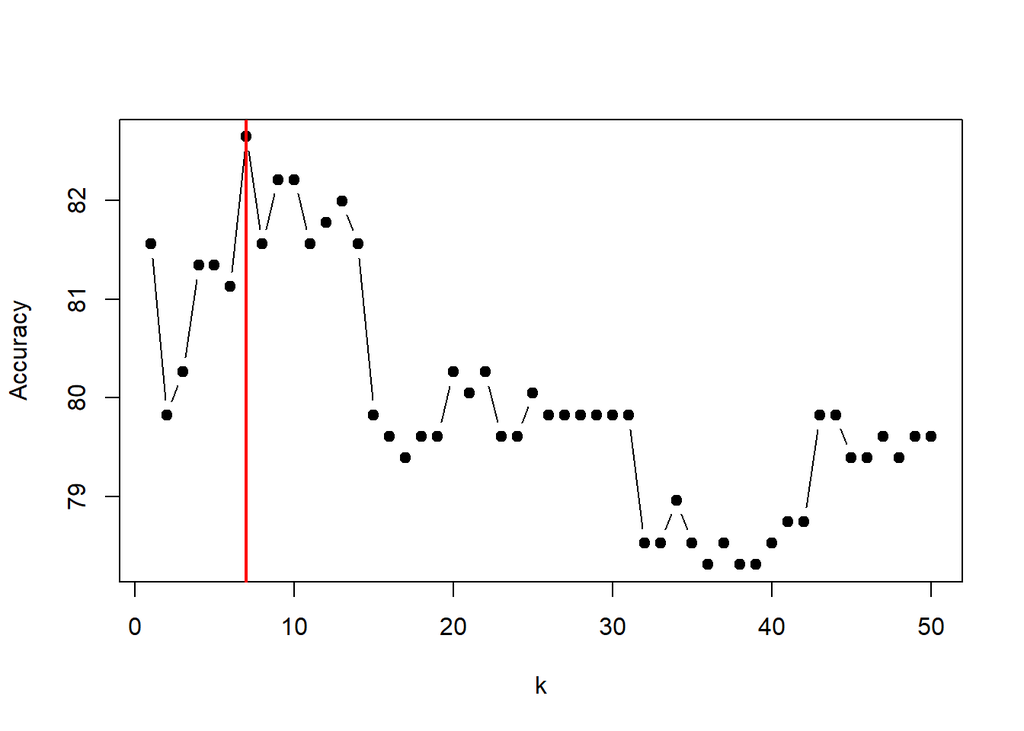

```r
plot(x = c(1:50), y = Accuracy, xlab = "k", pch = 19, type = "b")
abline(v = which.max(Accuracy), col = "red", lwd = 2)
```

```r
data.frame(Measure = c("Accuracy","Misclassification Rate","Sensitivity","Specificity"),
           Value = c(round(Accuracy[6],2),round(mis[6],2),round(sen[6],2),round(spe[6],2)))
```

```
##                  Measure Value
## 1               Accuracy 81.13
## 2 Misclassification Rate  0.19
## 3            Sensitivity  0.72
## 4            Specificity  0.86
```